# IBM’s employee resignation predictor

Guillaume BOTHIER, Cissy MARTINEZ, Ziad MIKHAEL, Amir SALAMEH

25th May 2018

## Business issue description

Attracting and retaining the talent within a company is a very strong concern for companies.  
Using the following data set, we would like to understand which factors are relevant when keeping an employee onboard.

## Analysis of the data set

The data has been downloaded from Kaggle: https://www.kaggle.com/pavansubhasht/ibm-hr-analytics-attrition-dataset/data0.

It consists of 1470 rows and 35 columns.  
Let us first have a look at the strucutre of the data and clean it a bit.

We remove the columns that are useless:

- EmployeeCount: all are 1
- Over18 : Yes for everyone
- StandardHours : everyone was 80

We also converted the “Attrition”" parameter from “Yes” to “1” and “No” to 0 and renamed it AttritionDummy.

## Check the Data

| Age | BusinessTravel | DailyRate | Department | DistanceFromHome | Education | EducationField | EmployeeNumber | EnvironmentSatisfaction | Gender | HourlyRate | JobInvolvement | JobLevel | JobRole | JobSatisfaction | MaritalStatus | MonthlyIncome | MonthlyRate | NumCompaniesWorked | OverTime | PercentSalaryHike | PerformanceRating | RelationshipSatisfaction | StockOptionLevel | TotalWorkingYears | TrainingTimesLastYear | WorkLifeBalance | YearsAtCompany | YearsInCurrentRole | YearsSinceLastPromotion | … |
| --- | --- | --- | --- | --- | --- | --- | --- | --- | --- | --- | --- | --- | --- | --- | --- | --- | --- | --- | --- | --- | --- | --- | --- | --- | --- | --- | --- | --- | --- | --- |
| 41 | Travel_Rarely | 1102 | Sales | 1 | 2 | Life Sciences | 1 | 2 | Female | 94 | 3 | 2 | Sales Executive | 4 | Single | 5993 | 19479 | 8 | Yes | 11 | 3 | 1 | 0 | 8 | 0 | 1 | 6 | 4 | 0 | … |
| 49 | Travel_Frequently | 279 | Research & Development | 8 | 1 | Life Sciences | 2 | 3 | Male | 61 | 2 | 2 | Research Scientist | 2 | Married | 5130 | 24907 | 1 | No | 23 | 4 | 4 | 1 | 10 | 3 | 3 | 10 | 7 | 1 | … |
| 37 | Travel_Rarely | 1373 | Research & Development | 2 | 2 | Other | 4 | 4 | Male | 92 | 2 | 1 | Laboratory Technician | 3 | Single | 2090 | 2396 | 6 | Yes | 15 | 3 | 2 | 0 | 7 | 3 | 3 | 0 | 0 | 0 | … |
| 33 | Travel_Frequently | 1392 | Research & Development | 3 | 4 | Life Sciences | 5 | 4 | Female | 56 | 3 | 1 | Research Scientist | 3 | Married | 2909 | 23159 | 1 | Yes | 11 | 3 | 3 | 0 | 8 | 3 | 3 | 8 | 7 | 3 | … |
| 27 | Travel_Rarely | 591 | Research & Development | 2 | 1 | Medical | 7 | 1 | Male | 40 | 3 | 1 | Laboratory Technician | 2 | Married | 3468 | 16632 | 9 | No | 12 | 3 | 4 | 1 | 6 | 3 | 3 | 2 | 2 | 2 | … |
| 32 | Travel_Frequently | 1005 | Research & Development | 2 | 2 | Life Sciences | 8 | 4 | Male | 79 | 3 | 1 | Laboratory Technician | 4 | Single | 3068 | 11864 | 0 | No | 13 | 3 | 3 | 0 | 8 | 2 | 2 | 7 | 7 | 3 | … |
| 59 | Travel_Rarely | 1324 | Research & Development | 3 | 3 | Medical | 10 | 3 | Female | 81 | 4 | 1 | Laboratory Technician | 1 | Married | 2670 | 9964 | 4 | Yes | 20 | 4 | 1 | 3 | 12 | 3 | 2 | 1 | 0 | 0 | … |
| 30 | Travel_Rarely | 1358 | Research & Development | 24 | 1 | Life Sciences | 11 | 4 | Male | 67 | 3 | 1 | Laboratory Technician | 3 | Divorced | 2693 | 13335 | 1 | No | 22 | 4 | 2 | 1 | 1 | 2 | 3 | 1 | 0 | 0 | … |
| 38 | Travel_Frequently | 216 | Research & Development | 23 | 3 | Life Sciences | 12 | 4 | Male | 44 | 2 | 3 | Manufacturing Director | 3 | Single | 9526 | 8787 | 0 | No | 21 | 4 | 2 | 0 | 10 | 2 | 3 | 9 | 7 | 1 | … |
| 36 | Travel_Rarely | 1299 | Research & Development | 27 | 3 | Medical | 13 | 3 | Male | 94 | 3 | 2 | Healthcare Representative | 3 | Married | 5237 | 16577 | 6 | No | 13 | 3 | 2 | 2 | 17 | 3 | 2 | 7 | 7 | 7 | … |
| 35 | Travel_Rarely | 809 | Research & Development | 16 | 3 | Medical | 14 | 1 | Male | 84 | 4 | 1 | Laboratory Technician | 2 | Married | 2426 | 16479 | 0 | No | 13 | 3 | 3 | 1 | 6 | 5 | 3 | 5 | 4 | 0 | … |
| 29 | Travel_Rarely | 153 | Research & Development | 15 | 2 | Life Sciences | 15 | 4 | Female | 49 | 2 | 2 | Laboratory Technician | 3 | Single | 4193 | 12682 | 0 | Yes | 12 | 3 | 4 | 0 | 10 | 3 | 3 | 9 | 5 | 0 | … |
| 31 | Travel_Rarely | 670 | Research & Development | 26 | 1 | Life Sciences | 16 | 1 | Male | 31 | 3 | 1 | Research Scientist | 3 | Divorced | 2911 | 15170 | 1 | No | 17 | 3 | 4 | 1 | 5 | 1 | 2 | 5 | 2 | 4 | … |
| 34 | Travel_Rarely | 1346 | Research & Development | 19 | 2 | Medical | 18 | 2 | Male | 93 | 3 | 1 | Laboratory Technician | 4 | Divorced | 2661 | 8758 | 0 | No | 11 | 3 | 3 | 1 | 3 | 2 | 3 | 2 | 2 | 1 | … |
| 28 | Travel_Rarely | 103 | Research & Development | 24 | 3 | Life Sciences | 19 | 3 | Male | 50 | 2 | 1 | Laboratory Technician | 3 | Single | 2028 | 12947 | 5 | Yes | 14 | 3 | 2 | 0 | 6 | 4 | 3 | 4 | 2 | 0 | … |
| 29 | Travel_Rarely | 1389 | Research & Development | 21 | 4 | Life Sciences | 20 | 2 | Female | 51 | 4 | 3 | Manufacturing Director | 1 | Divorced | 9980 | 10195 | 1 | No | 11 | 3 | 3 | 1 | 10 | 1 | 3 | 10 | 9 | 8 | … |
| 32 | Travel_Rarely | 334 | Research & Development | 5 | 2 | Life Sciences | 21 | 1 | Male | 80 | 4 | 1 | Research Scientist | 2 | Divorced | 3298 | 15053 | 0 | Yes | 12 | 3 | 4 | 2 | 7 | 5 | 2 | 6 | 2 | 0 | … |
| 22 | Non-Travel | 1123 | Research & Development | 16 | 2 | Medical | 22 | 4 | Male | 96 | 4 | 1 | Laboratory Technician | 4 | Divorced | 2935 | 7324 | 1 | Yes | 13 | 3 | 2 | 2 | 1 | 2 | 2 | 1 | 0 | 0 | … |
| 53 | Travel_Rarely | 1219 | Sales | 2 | 4 | Life Sciences | 23 | 1 | Female | 78 | 2 | 4 | Manager | 4 | Married | 15427 | 22021 | 2 | No | 16 | 3 | 3 | 0 | 31 | 3 | 3 | 25 | 8 | 3 | … |
| 38 | Travel_Rarely | 371 | Research & Development | 2 | 3 | Life Sciences | 24 | 4 | Male | 45 | 3 | 1 | Research Scientist | 4 | Single | 3944 | 4306 | 5 | Yes | 11 | 3 | 3 | 0 | 6 | 3 | 3 | 3 | 2 | 1 | … |
| 24 | Non-Travel | 673 | Research & Development | 11 | 2 | Other | 26 | 1 | Female | 96 | 4 | 2 | Manufacturing Director | 3 | Divorced | 4011 | 8232 | 0 | No | 18 | 3 | 4 | 1 | 5 | 5 | 2 | 4 | 2 | 1 | … |
| 36 | Travel_Rarely | 1218 | Sales | 9 | 4 | Life Sciences | 27 | 3 | Male | 82 | 2 | 1 | Sales Representative | 1 | Single | 3407 | 6986 | 7 | No | 23 | 4 | 2 | 0 | 10 | 4 | 3 | 5 | 3 | 0 | … |
| 34 | Travel_Rarely | 419 | Research & Development | 7 | 4 | Life Sciences | 28 | 1 | Female | 53 | 3 | 3 | Research Director | 2 | Single | 11994 | 21293 | 0 | No | 11 | 3 | 3 | 0 | 13 | 4 | 3 | 12 | 6 | 2 | … |
| 21 | Travel_Rarely | 391 | Research & Development | 15 | 2 | Life Sciences | 30 | 3 | Male | 96 | 3 | 1 | Research Scientist | 4 | Single | 1232 | 19281 | 1 | No | 14 | 3 | 4 | 0 | 0 | 6 | 3 | 0 | 0 | 0 | … |
| 34 | Travel_Rarely | 699 | Research & Development | 6 | 1 | Medical | 31 | 2 | Male | 83 | 3 | 1 | Research Scientist | 1 | Single | 2960 | 17102 | 2 | No | 11 | 3 | 3 | 0 | 8 | 2 | 3 | 4 | 2 | 1 | … |
| 53 | Travel_Rarely | 1282 | Research & Development | 5 | 3 | Other | 32 | 3 | Female | 58 | 3 | 5 | Manager | 3 | Divorced | 19094 | 10735 | 4 | No | 11 | 3 | 4 | 1 | 26 | 3 | 2 | 14 | 13 | 4 | … |
| 32 | Travel_Frequently | 1125 | Research & Development | 16 | 1 | Life Sciences | 33 | 2 | Female | 72 | 1 | 1 | Research Scientist | 1 | Single | 3919 | 4681 | 1 | Yes | 22 | 4 | 2 | 0 | 10 | 5 | 3 | 10 | 2 | 6 | … |
| 42 | Travel_Rarely | 691 | Sales | 8 | 4 | Marketing | 35 | 3 | Male | 48 | 3 | 2 | Sales Executive | 2 | Married | 6825 | 21173 | 0 | No | 11 | 3 | 4 | 1 | 10 | 2 | 3 | 9 | 7 | 4 | … |
| 44 | Travel_Rarely | 477 | Research & Development | 7 | 4 | Medical | 36 | 1 | Female | 42 | 2 | 3 | Healthcare Representative | 4 | Married | 10248 | 2094 | 3 | No | 14 | 3 | 4 | 1 | 24 | 4 | 3 | 22 | 6 | 5 | … |
| 46 | Travel_Rarely | 705 | Sales | 2 | 4 | Marketing | 38 | 2 | Female | 83 | 3 | 5 | Manager | 1 | Single | 18947 | 22822 | 3 | No | 12 | 3 | 4 | 0 | 22 | 2 | 2 | 2 | 2 | 2 | … |

[output cut: 1440 more lines]

The data we use here have the following descriptive statistics:

|  | min | 25 percent | median | mean | 75 percent | max | std |
| --- | --- | --- | --- | --- | --- | --- | --- |
| Age | 18 | 30.00 | 36.0 | 36.92 | 43.00 | 60 | 9.14 |
| DailyRate | 102 | 465.00 | 802.0 | 802.49 | 1157.00 | 1499 | 403.51 |
| Department | 1 | 2.00 | 2.0 | 2.26 | 3.00 | 3 | 0.53 |
| DistanceFromHome | 1 | 2.00 | 7.0 | 9.19 | 14.00 | 29 | 8.11 |
| Education | 1 | 2.00 | 3.0 | 2.91 | 4.00 | 5 | 1.02 |
| EducationField | 1 | 2.00 | 3.0 | 3.25 | 4.00 | 6 | 1.33 |
| EmployeeNumber | 1 | 491.25 | 1020.5 | 1024.87 | 1555.75 | 2068 | 602.02 |
| EnvironmentSatisfaction | 1 | 2.00 | 3.0 | 2.72 | 4.00 | 4 | 1.09 |
| Gender | 1 | 1.00 | 2.0 | 1.60 | 2.00 | 2 | 0.49 |
| HourlyRate | 30 | 48.00 | 66.0 | 65.89 | 83.75 | 100 | 20.33 |
| JobInvolvement | 1 | 2.00 | 3.0 | 2.73 | 3.00 | 4 | 0.71 |
| JobLevel | 1 | 1.00 | 2.0 | 2.06 | 3.00 | 5 | 1.11 |
| JobRole | 1 | 3.00 | 6.0 | 5.46 | 8.00 | 9 | 2.46 |
| JobSatisfaction | 1 | 2.00 | 3.0 | 2.73 | 4.00 | 4 | 1.10 |
| MaritalStatus | 1 | 2.00 | 2.0 | 2.10 | 3.00 | 3 | 0.73 |
| MonthlyIncome | 1009 | 2911.00 | 4919.0 | 6502.93 | 8379.00 | 19999 | 4707.96 |
| MonthlyRate | 2094 | 8047.00 | 14235.5 | 14313.10 | 20461.50 | 26999 | 7117.79 |
| NumCompaniesWorked | 0 | 1.00 | 2.0 | 2.69 | 4.00 | 9 | 2.50 |
| OverTime | 1 | 1.00 | 1.0 | 1.28 | 2.00 | 2 | 0.45 |
| PercentSalaryHike | 11 | 12.00 | 14.0 | 15.21 | 18.00 | 25 | 3.66 |
| PerformanceRating | 3 | 3.00 | 3.0 | 3.15 | 3.00 | 4 | 0.36 |
| RelationshipSatisfaction | 1 | 2.00 | 3.0 | 2.71 | 4.00 | 4 | 1.08 |
| StockOptionLevel | 0 | 0.00 | 1.0 | 0.79 | 1.00 | 3 | 0.85 |
| TotalWorkingYears | 0 | 6.00 | 10.0 | 11.28 | 15.00 | 40 | 7.78 |
| TrainingTimesLastYear | 0 | 2.00 | 3.0 | 2.80 | 3.00 | 6 | 1.29 |
| WorkLifeBalance | 1 | 2.00 | 3.0 | 2.76 | 3.00 | 4 | 0.71 |
| YearsAtCompany | 0 | 3.00 | 5.0 | 7.01 | 9.00 | 40 | 6.13 |
| YearsInCurrentRole | 0 | 2.00 | 3.0 | 4.23 | 7.00 | 18 | 3.62 |
| YearsSinceLastPromotion | 0 | 0.00 | 1.0 | 2.19 | 3.00 | 15 | 3.22 |
| YearsWithCurrManager | 0 | 2.00 | 3.0 | 4.12 | 7.00 | 17 | 3.57 |
| AttritionDummy | 1 | 1.00 | 1.0 | 1.16 | 1.00 | 2 | 0.37 |

## Initial brainstorming

- We could try to predict attrition by spliting the data set into training and testing. We are going to use a **logistic regression** tool: **glm**
- We could plot a correlation matrix to identify highly correlated factors
- We could use CTREE to make sens of the main important factor
- We could try to find clusters in the data set (unsupervised learning), look for patterns and adapt our HR strategy accordingly

## Correlation matrix

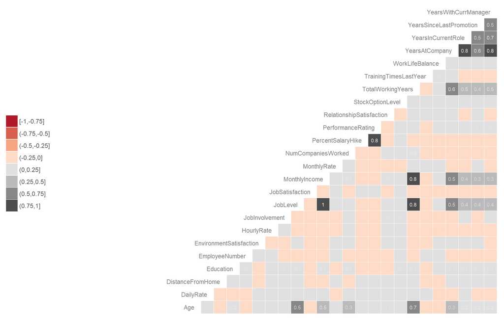

## Initial visualisation of the data set

The first step is to visualize the data and try to have a feeling of where it goes  
1 = YES : the employee left the company  
0 = NO : the employee hasn’t left the company (yet!)

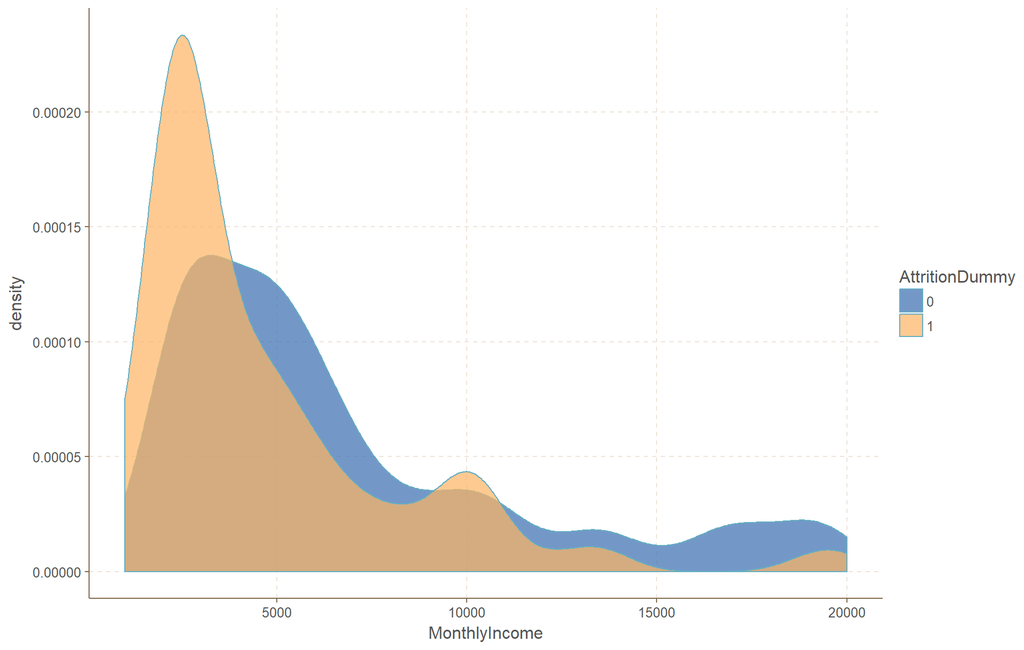

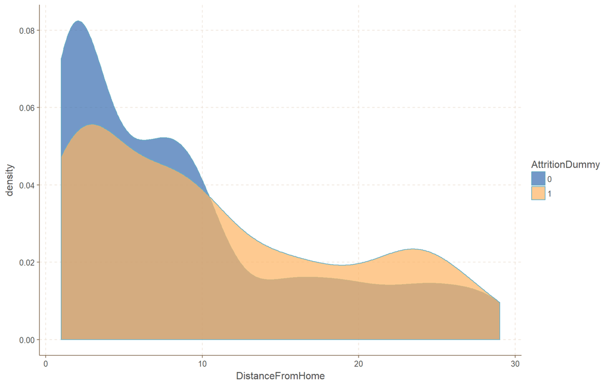

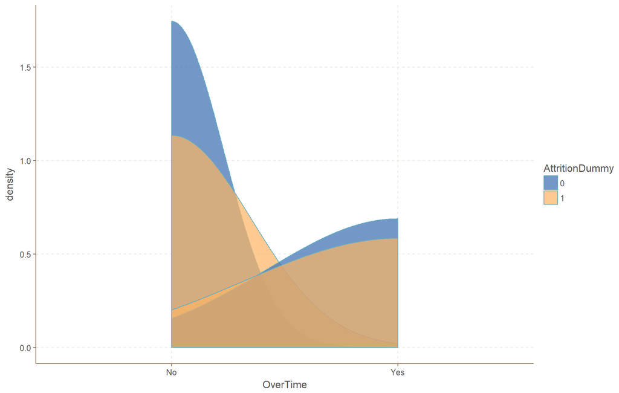

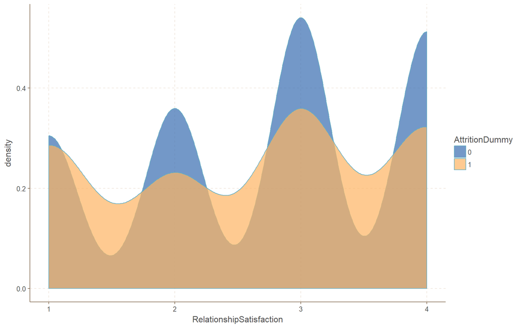

## CTREE model

We use CTREE model to try to make sense of the coefficients first.

‘data.frame’: 1470 obs. of 35 variables: $ ï..Age : int 41 49 37 33 27 32 59 30 38 36 … $ Attrition : num 1 0 1 0 0 0 0 0 0 0 … $ BusinessTravel : Factor w/ 3 levels “Non-Travel”,“Travel_Frequently”,..: 3 2 3 2 3 2 3 3 2 3 … $ DailyRate : int 1102 279 1373 1392 591 1005 1324 1358 216 1299 … $ Department : Factor w/ 3 levels “Human Resources”,..: 3 2 2 2 2 2 2 2 2 2 … $ DistanceFromHome : int 1 8 2 3 2 2 3 24 23 27 … $ Education : int 2 1 2 4 1 2 3 1 3 3 … $ EducationField : Factor w/ 6 levels “Human Resources”,..: 2 2 5 2 4 2 4 2 2 4 … $ EmployeeCount : int 1 1 1 1 1 1 1 1 1 1 … $ EmployeeNumber : int 1 2 4 5 7 8 10 11 12 13 … $ EnvironmentSatisfaction : int 2 3 4 4 1 4 3 4 4 3 … $ Gender : Factor w/ 2 levels “Female”,“Male”: 1 2 2 1 2 2 1 2 2 2 … $ HourlyRate : int 94 61 92 56 40 79 81 67 44 94 … $ JobInvolvement : int 3 2 2 3 3 3 4 3 2 3 … $ JobLevel : int 2 2 1 1 1 1 1 1 3 2 … $ JobRole : Factor w/ 9 levels “Healthcare Representative”,..: 8 7 3 7 3 3 3 3 5 1 … $ JobSatisfaction : int 4 2 3 3 2 4 1 3 3 3 … $ MaritalStatus : Factor w/ 3 levels “Divorced”,“Married”,..: 3 2 3 2 2 3 2 1 3 2 … $ MonthlyIncome : int 5993 5130 2090 2909 3468 3068 2670 2693 9526 5237 … $ MonthlyRate : int 19479 24907 2396 23159 16632 11864 9964 13335 8787 16577 … $ NumCompaniesWorked : int 8 1 6 1 9 0 4 1 0 6 … $ Over18 : Factor w/ 1 level “Y”: 1 1 1 1 1 1 1 1 1 1 … $ OverTime : Factor w/ 2 levels “No”,“Yes”: 2 1 2 2 1 1 2 1 1 1 … $ PercentSalaryHike : int 11 23 15 11 12 13 20 22 21 13 … $ PerformanceRating : int 3 4 3 3 3 3 4 4 4 3 … $ RelationshipSatisfaction: int 1 4 2 3 4 3 1 2 2 2 … $ StandardHours : int 80 80 80 80 80 80 80 80 80 80 … $ StockOptionLevel : int 0 1 0 0 1 0 3 1 0 2 … $ TotalWorkingYears : int 8 10 7 8 6 8 12 1 10 17 … $ TrainingTimesLastYear : int 0 3 3 3 3 2 3 2 2 3 … $ WorkLifeBalance : int 1 3 3 3 3 2 2 3 3 2 … $ YearsAtCompany : int 6 10 0 8 2 7 1 1 9 7 … $ YearsInCurrentRole : int 4 7 0 7 2 7 0 0 7 7 … $ YearsSinceLastPromotion : int 0 1 0 3 2 3 0 0 1 7 … $ YearsWithCurrManager : int 5 7 0 0 2 6 0 0 8 7 …

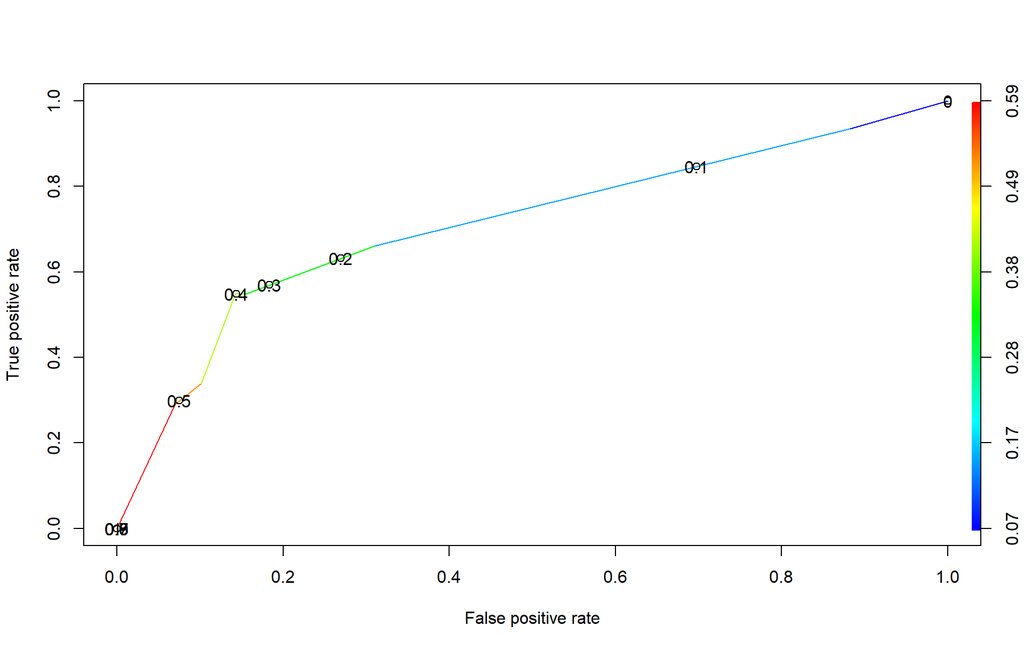

[1] 0.7096519

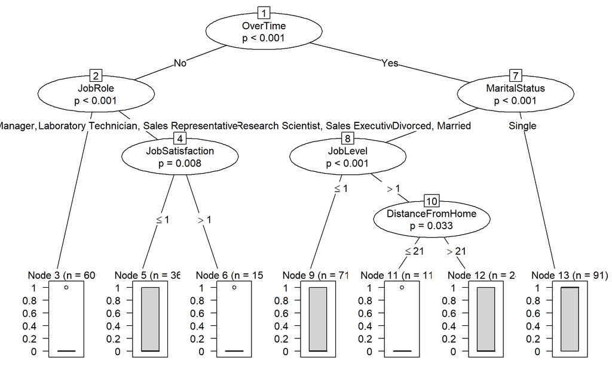

FALSE TRUE 0 271 45 1 28 34

The Accuracy of the model is 80.69%, we think we can do better!

## Logistic model

In this section we build a logistic model.

```r
pacman::p_load("caret","ROCR","lift","glmnet","MASS","e1071") #Check, and if needed install the necessary packages


#set a random number generation seed to ensure that the split is the same everytime
#set.seed(77850)
#set.seed(87700)
set.seed(2009)
inTrain <- createDataPartition(y = ProjectData$AttritionDummy ,
                               p = 1029/1470, list = FALSE) #1029 gives a 70% split

IBM.training <- ProjectData[ inTrain,]
IBM.testing <- ProjectData[ -inTrain,]

# Regression model using all the data
# Transform

fit<-glm(AttritionDummy~., data=IBM.training, family = binomial(link = 'logit'))

# Refining the previous model by finding the optimal AIC value
fit_AIC<-stepAIC(fit,direction = c("both"),trace = 0) #AIC stepwise want to maximize AIC

fit_AIC
```

Call: glm(formula = AttritionDummy ~ Age + BusinessTravel + DailyRate + DistanceFromHome + EducationField + EnvironmentSatisfaction + Gender + JobInvolvement + JobRole + JobSatisfaction + MaritalStatus + NumCompaniesWorked + OverTime + RelationshipSatisfaction + TrainingTimesLastYear + WorkLifeBalance + YearsInCurrentRole + YearsSinceLastPromotion + YearsWithCurrManager, family = binomial(link = “logit”), data = IBM.training)

Coefficients: (Intercept) Age  
1.9296479 -0.0496328  
BusinessTravelTravel_Frequently BusinessTravelTravel_Rarely  
1.9478723 0.8899259  
DailyRate DistanceFromHome  
-0.0005722 0.0462995  
EducationFieldLife Sciences EducationFieldMarketing  
-0.1724436 0.0808002  
EducationFieldMedical EducationFieldOther  
-0.3866290 -0.3670285  
EducationFieldTechnical Degree EnvironmentSatisfaction  
0.8771400 -0.4915435  
GenderMale JobInvolvement  
0.4093879 -0.6168922  
JobRoleHuman Resources JobRoleLaboratory Technician  
1.7528482 1.8271217  
JobRoleManager JobRoleManufacturing Director  
0.2905935 0.1110707  
JobRoleResearch Director JobRoleResearch Scientist  
-0.9564575 0.7105409  
JobRoleSales Executive JobRoleSales Representative  
1.3444554 2.4322512  
JobSatisfaction MaritalStatusMarried  
-0.3248320 0.6228199  
MaritalStatusSingle NumCompaniesWorked  
1.6850516 0.1546843  
OverTimeYes RelationshipSatisfaction  
2.0562427 -0.2607754  
TrainingTimesLastYear WorkLifeBalance  
-0.2757912 -0.3184810  
YearsInCurrentRole YearsSinceLastPromotion  
-0.1479819 0.2441207  
YearsWithCurrManager  
-0.0957581

Degrees of Freedom: 1029 Total (i.e. Null); 997 Residual Null Deviance: 909.7 Residual Deviance: 575.7 AIC: 641.7

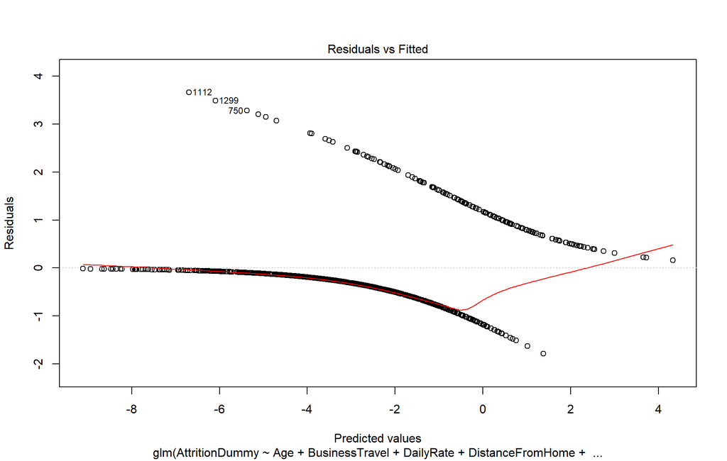

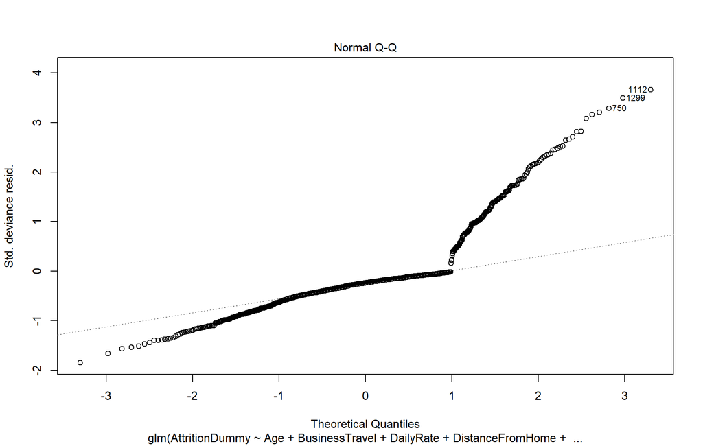

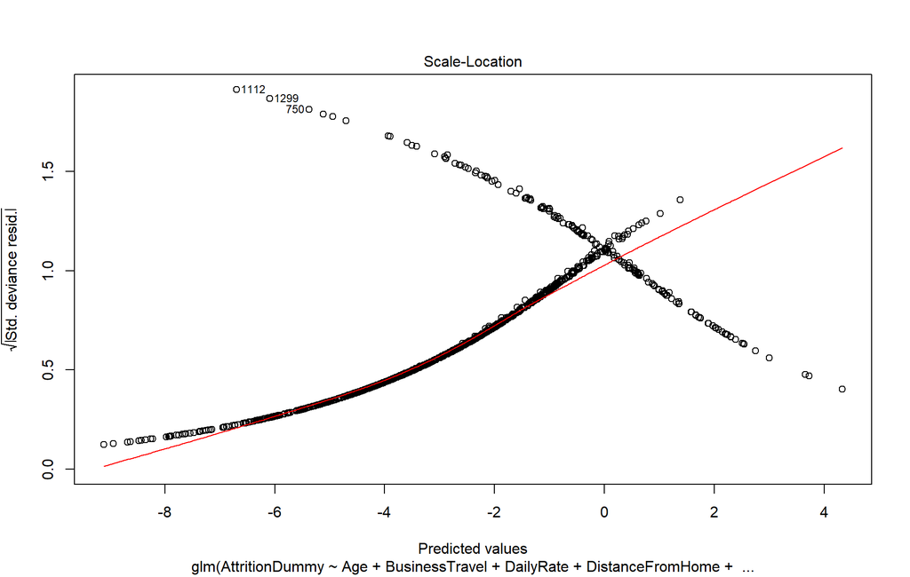

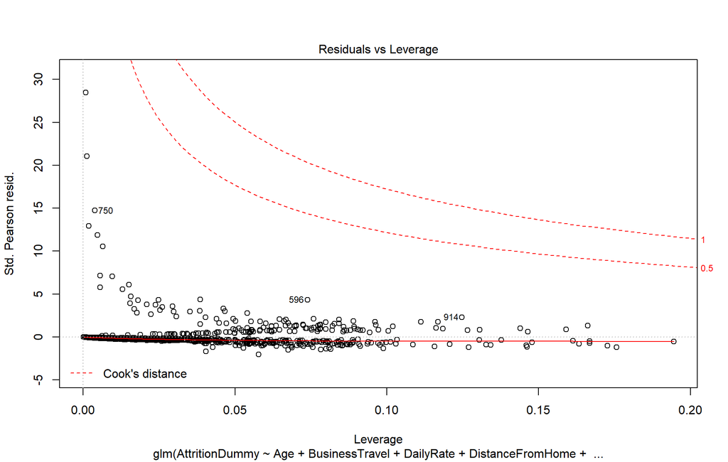

```r
plot(fit_AIC) #Error plots: similar nature to lm plots
```

```r
## ---- Prediction analysis --------------
#Comparison of our prediction with the testing sample
AttritionDummy.probability<-predict(fit_AIC,newdata=IBM.testing,type="response")
logistic_classification<-rep("1",0)
logistic_classification[AttritionDummy.probability<0.6073]="0" #Predict classification using 0.6073 threshold. Why 0.6073 - that's the average probability of being retained in the data. An alternative code: logistic_classification <- as.integer(logistic_probabilities > mean(testing$Retained.in.2012. == "1"))

logistic_classification <- as.factor(logistic_classification)
confusionMatrix(logistic_classification,IBM.testing$AttritionDummy) #Display confusion matrix
```

Confusion Matrix and Statistics

```
      Reference
```

Prediction 0 1 0 359 54 1 0 0

```
           Accuracy : 0.8692
             95% CI : (0.8329, 0.9002)
No Information Rate : 0.8692
P-Value [Acc > NIR] : 0.5362

              Kappa : 0
```

Mcnemar’s Test P-Value : 5.498e-13

```
        Sensitivity : 1.0000
        Specificity : 0.0000
     Pos Pred Value : 0.8692
     Neg Pred Value :    NaN
         Prevalence : 0.8692
     Detection Rate : 0.8692
```

Detection Prevalence : 1.0000  
Balanced Accuracy : 0.5000

```
   'Positive' Class : 0
```

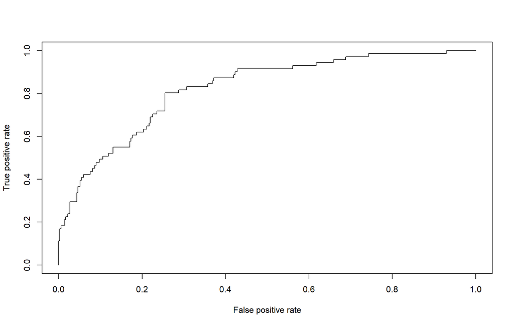

```r
#ROC Curve
logistic_ROC_prediction <- prediction(AttritionDummy.probability, IBM.testing$AttritionDummy)
logistic_ROC <- performance(logistic_ROC_prediction,"tpr","fpr") #Create ROC curve data
plot(logistic_ROC) #Plot ROC curve
```

```r
####AUC (area under curve)
auc.tmp <- performance(logistic_ROC_prediction,"auc") #Create AUC data
logistic_auc_testing <- as.numeric(auc.tmp@y.values) #Calculate AUC
logistic_auc_testing #Display AUC value: 90+% - excellent, 80-90% - very good, 70-80% - good, 60-70% - so so, below 60% - not much value
```

[1] 0.8219398

## Next iteration

- In the next iteration, we will try to improve the results by engineering new features

# Second loop : data cleaning

## Correlation matrix

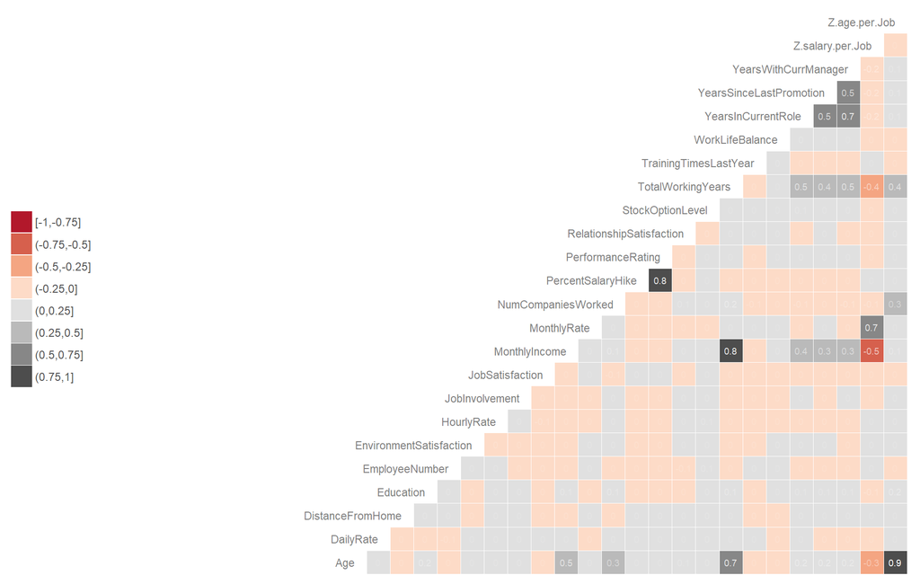

## CTREE model number 2

We use CTREE model to try to make sense of the coefficients first.

‘data.frame’: 1470 obs. of 38 variables: $ Age : int 41 49 37 33 27 32 59 30 38 36 … $ Attrition : num 1 0 1 0 0 0 0 0 0 0 … $ BusinessTravel : Factor w/ 3 levels “Non-Travel”,“Travel_Frequently”,..: 3 2 3 2 3 2 3 3 2 3 … $ DailyRate : int 1102 279 1373 1392 591 1005 1324 1358 216 1299 … $ Department : Factor w/ 3 levels “Human Resources”,..: 3 2 2 2 2 2 2 2 2 2 … $ DistanceFromHome : int 1 8 2 3 2 2 3 24 23 27 … $ Education : int 2 1 2 4 1 2 3 1 3 3 … $ EducationField : Factor w/ 6 levels “Human Resources”,..: 2 2 5 2 4 2 4 2 2 4 … $ EmployeeCount : int 1 1 1 1 1 1 1 1 1 1 … $ EmployeeNumber : int 1 2 4 5 7 8 10 11 12 13 … $ EnvironmentSatisfaction : int 2 3 4 4 1 4 3 4 4 3 … $ Gender : Factor w/ 2 levels “Female”,“Male”: 1 2 2 1 2 2 1 2 2 2 … $ HourlyRate : int 94 61 92 56 40 79 81 67 44 94 … $ JobInvolvement : int 3 2 2 3 3 3 4 3 2 3 … $ JobLevel : int 2 2 1 1 1 1 1 1 3 2 … $ JobRole : Factor w/ 9 levels “Healthcare Representative”,..: 8 7 3 7 3 3 3 3 5 1 … $ JobSatisfaction : int 4 2 3 3 2 4 1 3 3 3 … $ MaritalStatus : Factor w/ 3 levels “Divorced”,“Married”,..: 3 2 3 2 2 3 2 1 3 2 … $ MonthlyIncome : int 5993 5130 2090 2909 3468 3068 2670 2693 9526 5237 … $ MonthlyRate : int 19479 24907 2396 23159 16632 11864 9964 13335 8787 16577 … $ NumCompaniesWorked : int 8 1 6 1 9 0 4 1 0 6 … $ Over18 : Factor w/ 1 level “Y”: 1 1 1 1 1 1 1 1 1 1 … $ OverTime : Factor w/ 2 levels “No”,“Yes”: 2 1 2 2 1 1 2 1 1 1 … $ PercentSalaryHike : int 11 23 15 11 12 13 20 22 21 13 … $ PerformanceRating : int 3 4 3 3 3 3 4 4 4 3 … $ RelationshipSatisfaction: int 1 4 2 3 4 3 1 2 2 2 … $ StandardHours : int 80 80 80 80 80 80 80 80 80 80 … $ StockOptionLevel : int 0 1 0 0 1 0 3 1 0 2 … $ TotalWorkingYears : int 8 10 7 8 6 8 12 1 10 17 … $ TrainingTimesLastYear : int 0 3 3 3 3 2 3 2 2 3 … $ WorkLifeBalance : int 1 3 3 3 3 2 2 3 3 2 … $ YearsAtCompany : int 6 10 0 8 2 7 1 1 9 7 … $ YearsInCurrentRole : int 4 7 0 7 2 7 0 0 7 7 … $ YearsSinceLastPromotion : int 0 1 0 3 2 3 0 0 1 7 … $ YearsWithCurrManager : int 5 7 0 0 2 6 0 0 8 7 … $ Z.salary.per.Job : num 5.304 18.084 -0.731 16.625 11.645 … $ Z.age.per.Job : num 0.508 1.718 0.345 -0.144 -0.843 … $ Generic.role : int 1 0 0 0 0 0 0 0 1 1 …

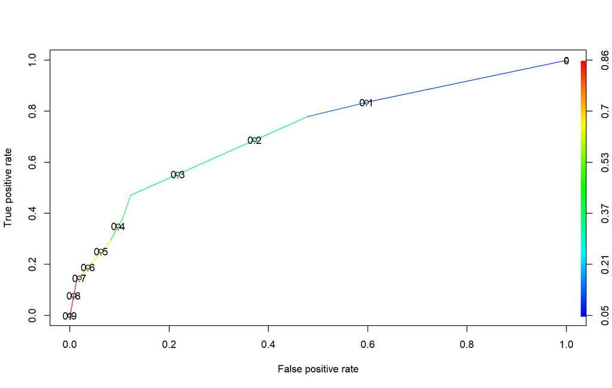

[1] 0.7191406

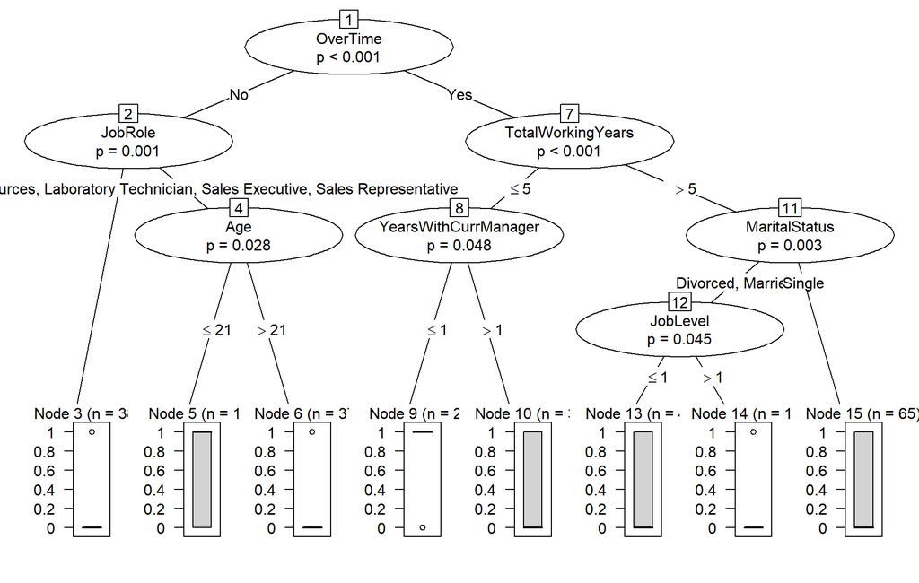

FALSE TRUE 0 294 26 1 48 20

## Logistic model number 2

In this section we build a logistic model.

```r
pacman::p_load("caret","ROCR","lift","glmnet","MASS","e1071") #Check, and if needed install the necessary packages


#set a random number generation seed to ensure that the split is the same everytime
#set.seed(77850)
#set.seed(87700)
set.seed(2009)
inTrain <- createDataPartition(y = ProjectData$AttritionDummy ,
                               p = 1029/1470, list = FALSE) #1029 gives a 70% split

IBM.training <- ProjectData[ inTrain,]
IBM.testing <- ProjectData[ -inTrain,]

# Regression model using all the data
# Transform

fit<-glm(AttritionDummy~., data=IBM.training, family = binomial(link = 'logit'))

# Refining the previous model by finding the optimal AIC value
fit_AIC<-stepAIC(fit,direction = c("both"),trace = 0) #AIC stepwise want to maximize AIC

fit_AIC
```

Call: glm(formula = AttritionDummy ~ Age + BusinessTravel + DailyRate + DistanceFromHome + EducationField + EnvironmentSatisfaction + Gender + JobInvolvement + JobRole + JobSatisfaction + MaritalStatus + NumCompaniesWorked + OverTime + RelationshipSatisfaction + TrainingTimesLastYear + WorkLifeBalance + YearsInCurrentRole + YearsSinceLastPromotion + YearsWithCurrManager + Z.age.per.Job, family = binomial(link = “logit”), data = IBM.training)

Coefficients: (Intercept) Age  
23.0230903 -0.5809324  
BusinessTravelTravel_Frequently BusinessTravelTravel_Rarely  
2.0222624 0.9438634  
DailyRate DistanceFromHome  
-0.0005556 0.0471075  
EducationFieldLife Sciences EducationFieldMarketing  
-0.1818557 0.0824049  
EducationFieldMedical EducationFieldOther  
-0.3715992 -0.3638862  
EducationFieldTechnical Degree EnvironmentSatisfaction  
0.8611102 -0.4928465  
GenderMale JobInvolvement  
0.3969373 -0.6334331  
JobRoleHuman Resources JobRoleLaboratory Technician  
-0.4746754 -1.2145413  
JobRoleManager JobRoleManufacturing Director  
3.8959736 -0.7214873  
JobRoleResearch Director JobRoleResearch Scientist  
1.1766244 -2.2747905  
JobRoleSales Executive JobRoleSales Representative  
-0.2010061 -2.5775608  
JobSatisfaction MaritalStatusMarried  
-0.3226601 0.6066066  
MaritalStatusSingle NumCompaniesWorked  
1.6473461 0.1556802  
OverTimeYes RelationshipSatisfaction  
2.0642522 -0.2604376  
TrainingTimesLastYear WorkLifeBalance  
-0.2683881 -0.3132445  
YearsInCurrentRole YearsSinceLastPromotion  
-0.1458476 0.2483355  
YearsWithCurrManager Z.age.per.Job  
-0.0982099 4.3989624

Degrees of Freedom: 1029 Total (i.e. Null); 996 Residual Null Deviance: 909.7 Residual Deviance: 573.1 AIC: 641.1

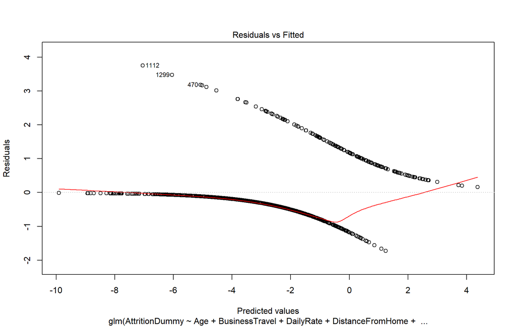

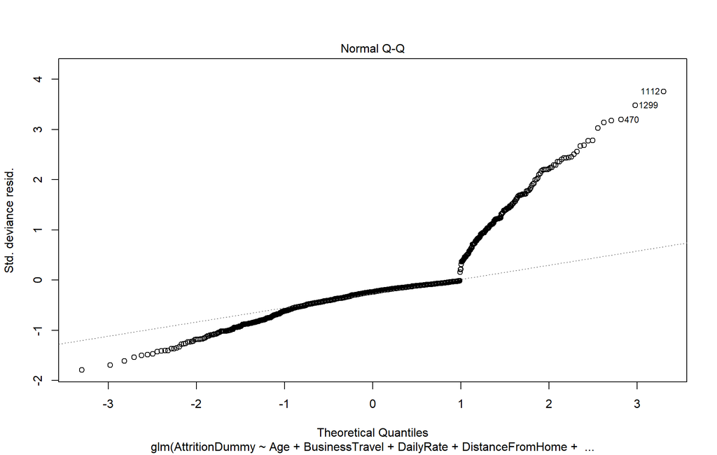

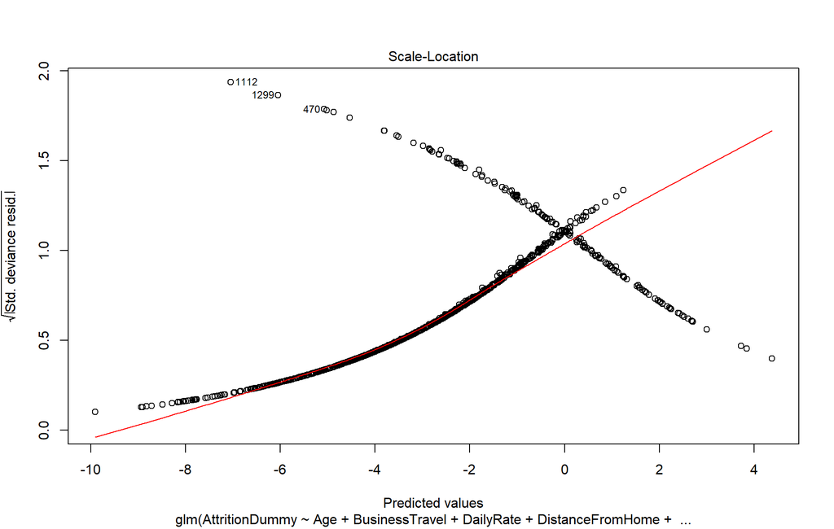

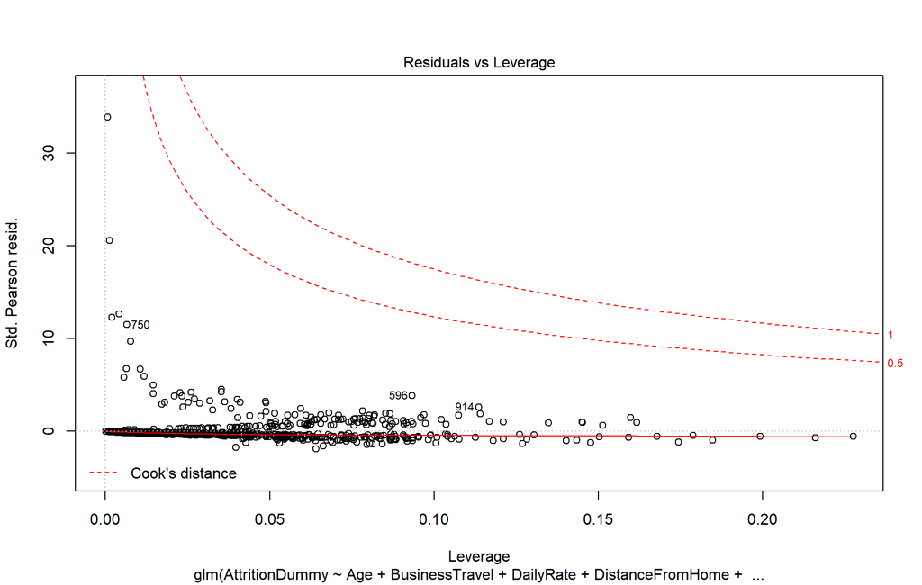

```r
plot(fit_AIC) #Error plots: similar nature to lm plots
```

```r
## ---- Prediction analysis --------------
#Comparison of our prediction with the testing sample
AttritionDummy.probability<-predict(fit_AIC,newdata=IBM.testing,type="response")
logistic_classification<-rep("1",0)
logistic_classification[AttritionDummy.probability<0.6073]="0" #Predict classification using 0.6073 threshold. Why 0.6073 - that's the average probability of being retained in the data. An alternative code: logistic_classification <- as.integer(logistic_probabilities > mean(testing$Retained.in.2012. == "1"))

logistic_classification <- as.factor(logistic_classification)
confusionMatrix(logistic_classification,IBM.testing$AttritionDummy) #Display confusion matrix
```

Confusion Matrix and Statistics

```
      Reference
```

Prediction 0 1 0 360 54 1 0 0

```
           Accuracy : 0.8696
             95% CI : (0.8333, 0.9005)
No Information Rate : 0.8696
P-Value [Acc > NIR] : 0.5362

              Kappa : 0
```

Mcnemar’s Test P-Value : 5.498e-13

```
        Sensitivity : 1.0000
        Specificity : 0.0000
     Pos Pred Value : 0.8696
     Neg Pred Value :    NaN
         Prevalence : 0.8696
     Detection Rate : 0.8696
```

Detection Prevalence : 1.0000  
Balanced Accuracy : 0.5000

```
   'Positive' Class : 0
```

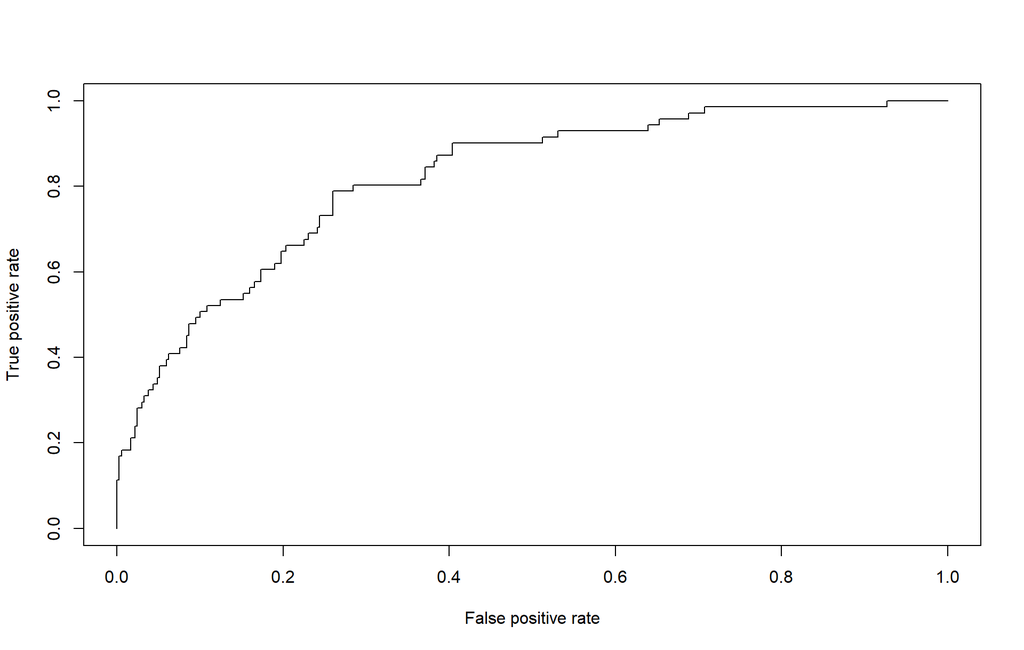

```r
#ROC Curve
logistic_ROC_prediction <- prediction(AttritionDummy.probability, IBM.testing$AttritionDummy)
logistic_ROC <- performance(logistic_ROC_prediction,"tpr","fpr") #Create ROC curve data
plot(logistic_ROC) #Plot ROC curve
```

```r
####AUC (area under curve)
auc.tmp <- performance(logistic_ROC_prediction,"auc") #Create AUC data
logistic_auc_testing <- as.numeric(auc.tmp@y.values) #Calculate AUC
logistic_auc_testing #Display AUC value: 90+% - excellent, 80-90% - very good, 70-80% - good, 60-70% - so so, below 60% - not much value
```

[1] 0.8184282